# VSTM Notebook

# **VSTM PRE DATA ANALYSIS**

NOTE: missing data from sub161 (from control group)

N=55 (Control+Experimental) There is a 3rd undefined group for those that have completed this task, but have dropped out for one reason or another.

## **Data Prep**

Getting the Data ready for analysis Defaults: R uses dummy coding as it’s default. In this sample, the control group and the simboth condition will be the dummy variables in the analysis. So all Estimates are relative to these dummy variables

### Load Requisite R Packages

note: some of these may not actually be used.

```r
library(ggplot2)
library(lme4)
library(languageR)
library(lmerTest) #give p-values from mixed models
library(influence.ME)
library(plyr) # magic
library(scales) #for making percents on the y-axis of graphs
```

### Read in the dataset (in current directory)

```r
VSTM_data = read.table("VSTM_R_format.csv", header = TRUE, sep = ",")
```

### Omit missing data (e.g. from practice trials)

```r
VSTM_data = na.omit(VSTM_data)
head(VSTM_data, n = 20)
```

### Omit the Undefined group from the data and specify group as a factor

```r
VSTM_data <- subset(VSTM_data,group=="Control" | group=="Experimental")
VSTM_data$group <- factor(VSTM_data$group)
summary(VSTM_data)
contrasts(VSTM_data$group)
```

### Omit the Practice stimtype and specify stimtype as a factor

```r
VSTM_data <- subset(VSTM_data,stimtype=="SimBoth" | stimtype=="SimColour" | stimtype=="SimShape")
VSTM_data$stimtype <- factor(VSTM_data$stimtype)
summary(VSTM_data)
contrasts(VSTM_data$stimtype)
```

### Isolate the session to the first session

```r
VSTM_data_pre <- subset(VSTM_data, session==1)
VSTM_data_pre$session <- factor(VSTM_data_pre$session)
summary(VSTM_data_pre)
```

### specify subject as a factor

```r
VSTM_data_pre$subject <- as.factor(VSTM_data_pre$subject)

summary(VSTM_data_pre)
```

## **VSTM Accuracy Analysis**

### Print out binary accuracy data for each subject for each group

```r
#Control Group Data
VSTM_data_pre_control <- subset(VSTM_data_pre, group=="Control")
#change binary data to a percent
VSTM_data_pre_control_percent <- ddply(VSTM_data_pre_control, .(stimtype, subject), summarize, ACC_perc = mean(ACC))

#Experimental Group Data
VSTM_data_pre_experimental <- subset(VSTM_data_pre, group=="Experimental")
#change binary data to a percent
VSTM_data_pre_experimental_percent <- ddply(VSTM_data_pre_experimental, .(stimtype, subject), summarize, ACC_perc = mean(ACC))

ggplot(data = VSTM_data_pre_control_percent, aes( x = stimtype, y = ACC_perc)) + geom_bar(stat = "identity", width = 0.5) + facet_wrap(~subject) + scale_y_continuous(labels=percent) + scale_x_discrete(labels=c("Both","Color","Shape")) + ggtitle("Control")

ggplot(data = VSTM_data_pre_experimental_percent, aes( x = stimtype, y = ACC_perc)) + geom_bar(stat = "identity", width = 0.5) + facet_wrap(~subject) + scale_y_continuous(labels=percent) +  scale_x_discrete(labels=c("Both","Color","Shape")) + ggtitle("Experimental")
```

[output not shown]

**Conclusion**: Subjects appear to be less accurate when trying to match both shape and color as opposed to either shape or color. No worrying data points.

### Model Accuracy (Logit)

```r
VSTM_ACC_model<-glmer(ACC ~ group*stimtype + (1|subject), family=binomial, data=VSTM_data_pre, verbose=TRUE)
summary(VSTM_ACC_model)
```

[output not shown]

**Conclusion**: there is no group effect (as expected), participants are more accurate when they only have to guess if they saw one attribute (color or shape) versus both (color & shape) (as expected)

## **VSTM Reaction Time Analysis**

### Format RT data

(subset for RTs when they are accurate, greater than 200ms, and less than 5000 ms) (speed not important in this analysis) See how many observations are lost when we subset the data

```r
#all observations
print("All Data")
```

```
[1] "All Data"
```

```r
All_data <- length(VSTM_data_pre$RT)
summary(VSTM_data_pre)
```

```
    subject     session            group           stimtype         ACC               RT
 5      : 204   1:11213   Control     :5712   SimBoth  :3733   Min.   :0.0000   Min.   :    0
 6      : 204             Experimental:5501   SimColour:3740   1st Qu.:0.0000   1st Qu.: 1038
 7      : 204                                 SimShape :3740   Median :1.0000   Median : 1310
 8      : 204                                                  Mean   :0.7218   Mean   : 1519
 9      : 204                                                  3rd Qu.:1.0000   3rd Qu.: 1706
 10     : 204                                                  Max.   :1.0000   Max.   :27493
 (Other):9989
```

```r
#remove innacurate responses
print("Removed innacurate trials (from all data dataframe)")
```

```
[1] "Removed innacurate trials (from all data dataframe)"
```

```r
VSTM_data_pre_RT <- subset(VSTM_data_pre, ACC==1)
All_acc_data <- length(VSTM_data_pre_RT$RT)
summary(VSTM_data_pre_RT)
```

```
    subject     session           group           stimtype         ACC          RT
 45     : 169   1:8093   Control     :4113   SimBoth  :2422   Min.   :1   Min.   :  200
 12     : 167            Experimental:3980   SimColour:2987   1st Qu.:1   1st Qu.: 1016
 43     : 165                                SimShape :2684   Median :1   Median : 1274
 87     : 163                                                 Mean   :1   Mean   : 1449
 65     : 162                                                 3rd Qu.:1   3rd Qu.: 1637
 76     : 160                                                 Max.   :1   Max.   :27493
 (Other):7107
```

```r
#remove short and long RTs
print("Removed slow and fast RTs")
```

```
[1] "Removed slow and fast RTs"
```

```r
VSTM_data_pre_RT <- subset(VSTM_data_pre_RT, RT>200 & RT<5000)
filtered_data <- length(VSTM_data_pre_RT$RT)
summary(VSTM_data_pre_RT)
```

```
    subject     session           group           stimtype         ACC          RT
 45     : 168   1:8046   Control     :4080   SimBoth  :2406   Min.   :1   Min.   : 210
 12     : 167            Experimental:3966   SimColour:2978   1st Qu.:1   1st Qu.:1015
 43     : 165                                SimShape :2662   Median :1   Median :1272
 87     : 163                                                 Mean   :1   Mean   :1413
 65     : 161                                                 3rd Qu.:1   3rd Qu.:1627
 76     : 160                                                 Max.   :1   Max.   :4995
 (Other):7062
```

```r
print("Percentage of Data Removed")
```

```
[1] "Percentage of Data Removed"
```

```r
perc_data_rm <- (1 - (filtered_data/All_acc_data) ) * 100
perc_data_rm
```

```
[1] 0.5807488
```

**Conclusion**: Only half a percentage point of data removed, well within acceptable standards

### Graph RT data

Note: Only looking at RT data by condition.

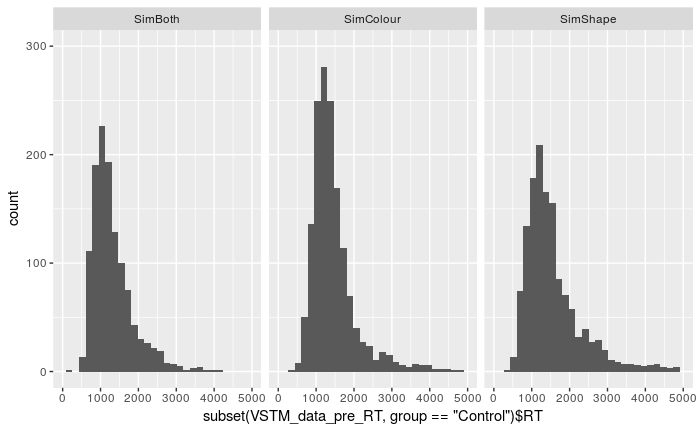

```r
#hist(subset(VSTM_data_pre_RT, group=="Control")$RT,ylim=c(0,1600))
#hist(subset(VSTM_data_pre_RT, group=="Experimental")$RT,ylim=c(0,1600))
ggplot(data = subset(VSTM_data_pre_RT, group=="Control"), aes(subset(VSTM_data_pre_RT, group=="Control")$RT)) + geom_histogram() + facet_wrap(~subset(VSTM_data_pre_RT, group=="Control")$stimtype) + scale_y_continuous(limits = c(0,300)) + scale_x_continuous(limits = c(0,5000))
```

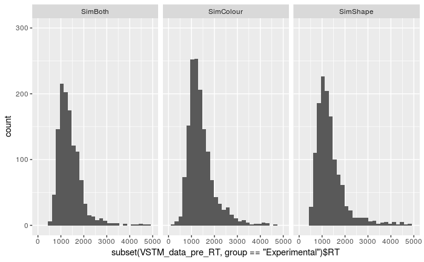

```r
ggplot(data = subset(VSTM_data_pre_RT, group=="Experimental"), aes(subset(VSTM_data_pre_RT, group=="Experimental")$RT)) + geom_histogram() + facet_wrap(~subset(VSTM_data_pre_RT, group=="Experimental")$stimtype) + scale_y_continuous(limits = c(0,300)) + scale_x_continuous(limits = c(0,5000))
```

**Conclusion**: This data shows some right skew (outliers to the right), trying log transform.

### Log Transform RT data

```r
VSTM_data_pre_RT$log_RT <- log(1/VSTM_data_pre_RT$RT)
```

### Graph logged RT data

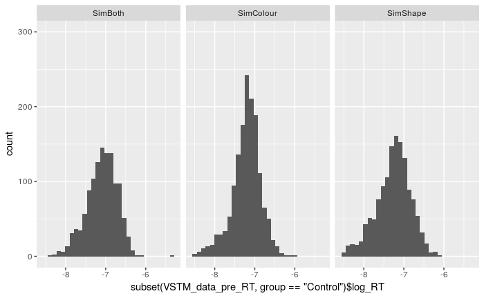

```r
#hist(subset(VSTM_data_pre_RT, group=="Control")$RT,ylim=c(0,1600))
#hist(subset(VSTM_data_pre_RT, group=="Experimental")$RT,ylim=c(0,1600))
ggplot(data = subset(VSTM_data_pre_RT, group=="Control"), aes(subset(VSTM_data_pre_RT, group=="Control")$log_RT)) + geom_histogram() + facet_wrap(~subset(VSTM_data_pre_RT, group=="Control")$stimtype) + scale_y_continuous(limits = c(0,300))
```

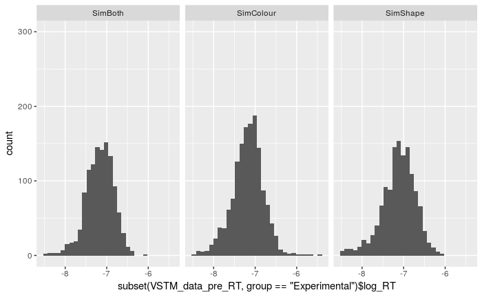

```r
ggplot(data = subset(VSTM_data_pre_RT, group=="Experimental"), aes(subset(VSTM_data_pre_RT, group=="Experimental")$log_RT)) + geom_histogram() + facet_wrap(~subset(VSTM_data_pre_RT, group=="Experimental")$stimtype) + scale_y_continuous(limits = c(0,300))
```

**Conclusion**: Data Appears to benefit from transform, using log RT for analysis

### Model log RT

```r
VSTM_RT_model <- lmer(log_RT ~ group*stimtype + (1|subject), data = VSTM_data_pre_RT)
summary(VSTM_RT_model)
```

```
Linear mixed model fit by REML
t-tests use  Satterthwaite approximations to degrees of freedom ['lmerMod']
Formula: log_RT ~ group * stimtype + (1 | subject)
   Data: VSTM_data_pre_RT

REML criterion at convergence: 5087.2

Scaled residuals:
    Min      1Q  Median      3Q     Max
-4.3361 -0.5495  0.1082  0.6664  4.8236

Random effects:
 Groups   Name        Variance Std.Dev.
 subject  (Intercept) 0.03886  0.1971
 Residual             0.10680  0.3268
Number of obs: 8046, groups:  subject, 55

Fixed effects:
                                      Estimate Std. Error         df  t value Pr(>|t|)
(Intercept)                         -7.204e+00  3.842e-02  5.800e+01 -187.489  < 2e-16 ***
groupExperimental                    5.130e-02  5.482e-02  5.800e+01    0.936    0.353
stimtypeSimColour                    7.268e-02  1.262e-02  7.987e+03    5.760 8.74e-09 ***
stimtypeSimShape                    -5.198e-02  1.293e-02  7.988e+03   -4.020 5.87e-05 ***
groupExperimental:stimtypeSimColour -2.526e-02  1.793e-02  7.987e+03   -1.409    0.159
groupExperimental:stimtypeSimShape  -9.424e-03  1.841e-02  7.988e+03   -0.512    0.609
---
Signif. codes:  0 ‘***’ 0.001 ‘**’ 0.01 ‘*’ 0.05 ‘.’ 0.1 ‘ ’ 1

Correlation of Fixed Effects:
            (Intr) grpExp stmtSC stmtSS grE:SC
grpExprmntl -0.701
stmtypSmClr -0.182  0.128
stmtypSmShp -0.178  0.125  0.542
grpExprm:SC  0.128 -0.181 -0.704 -0.382
grpExprm:SS  0.125 -0.176 -0.381 -0.702  0.539
```

## **Conclusions**

good: No overall group differences or group interactions.

bad: Nothing that I can find, data are in good order.